# Reproducible Research: Project 01

Thiago Veras

July 13, 2015

### Dataset: Activity monitoring data

#### The variables included in this dataset are:

- steps: Number of steps taking in a 5-minute interval (missing values are coded as NA)
- date: The date on which the measurement was taken in YYYY-MM-DD format
- interval: Identifier for the 5-minute interval in which measurement was taken

#### The dataset is stored in a comma-separated-value (CSV) file and there are a total of 17,568 observations in this dataset.

### Loading and preprocessing the data

#### 1. Loading data

```r
# Loading the data
raw_data <- read.csv("activity.csv", colClasses = c("numeric", "Date", "numeric"))

# Printing the head of the raw data
head(raw_data)
```

```
##   steps       date interval
## 1    NA 2012-10-01        0
## 2    NA 2012-10-01        5
## 3    NA 2012-10-01       10
## 4    NA 2012-10-01       15
## 5    NA 2012-10-01       20
## 6    NA 2012-10-01       25
```

#### 2. Preprocessing the data

```r
# Create the activity data.frame
activity_data <- data.frame(date=raw_data$date,
                            weekday=tolower(weekdays(raw_data$date)),
                            interval=raw_data$interval,
                            steps=raw_data$steps)

# Printing the head of activity data.frame
head(activity_data)
```

```
##         date weekday interval steps
## 1 2012-10-01  monday        0    NA
## 2 2012-10-01  monday        5    NA
## 3 2012-10-01  monday       10    NA
## 4 2012-10-01  monday       15    NA
## 5 2012-10-01  monday       20    NA
## 6 2012-10-01  monday       25    NA
```

### What is mean total number of steps taken per day?

#### 1. Calculating the total number of steps taken per day

```r
# Aggregating steps by date
aggregated_activity_na_rm <- aggregate(steps ~ date, activity_data, sum, na.rm = TRUE)

# Renaming the second attribute
names(aggregated_activity_na_rm)[2] <- "total_steps"
```

#### 2. Making a histogram of the total number of steps taken each day

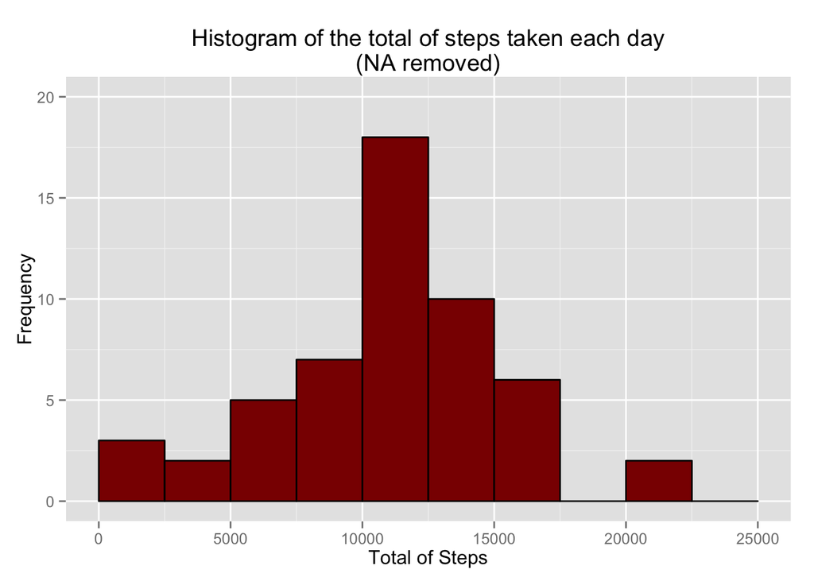

```r
# Importing the ggplot2 library
library(ggplot2)

# Ploting the graph
ggplot(aggregated_activity_na_rm, aes(x=total_steps)) +
    geom_histogram(binwidth=1000, breaks=seq(from=0, to=25000, by=2500), colour="black", fill="darkred") +
    ylim(0,20) +
    ggtitle("Histogram of the total of steps taken each day\n(NA removed)") +
    xlab("Total of Steps") +
    ylab("Frequency")
```

#### 3. Calculating and reporting the mean and median of the total number of steps taken per day

```r
# Calculating the mean
mean(aggregated_activity_na_rm$total_steps, na.rm=TRUE)
```

```
## [1] 10766.19
```

```r
# Calculating the median
median(aggregated_activity_na_rm$total_steps, na.rm=TRUE)
```

```
## [1] 10765
```

### What is the average daily activity pattern?

#### 1. Making a time series plot of the 5-minute interval (x-axis) and the average number of steps taken, averaged across all days (y-axis)

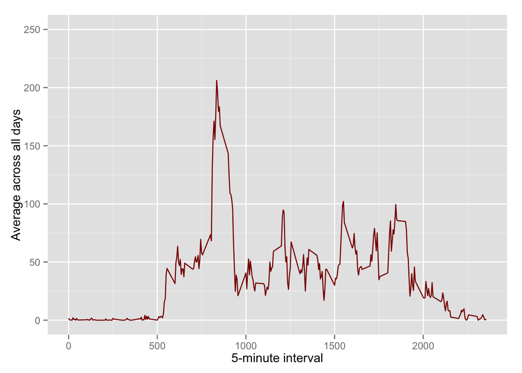

```r
# Importing the ggplot2 library
library(ggplot2)

# Aggregating average of steps by interval
average_activity_by_interval <- aggregate(steps ~ interval, activity_data, mean, na.rm = TRUE)

ggplot(data=average_activity_by_interval, aes(x=interval, y=steps)) +
    geom_line(binwidth=100, breaks=seq(from=0, to=3000, by=500), colour="darkred") +
    ylim(0,250) +
    xlab("5-minute interval") +
    ylab("Average across all days")
```

#### 2. Which 5-minute interval, on average across all the days in the dataset, contains the maximum number of steps?

```r
average_activity_by_interval[which.max(average_activity_by_interval$steps),]
```

```
##     interval    steps
## 104      835 206.1698
```

### Imputing missing values

#### Note that there are a number of days/intervals where there are missing values (coded as NA). The presence of missing days may introduce bias into some calculations or summaries of the data.

#### 1. Calculating and reporting the total number of missing values in the dataset.

```r
total_na <- sum(is.na(activity_data$steps))
total_na
```

```
## [1] 2304
```

#### 3. Creating a new dataset that is equal to the original dataset but with the missing data filled in.

```r
# Finding the NA positions
na_positions <- which(is.na(activity_data$steps))

# Creating a vector of means
mean_vector <- rep(mean(activity_data$steps, na.rm=TRUE), times=length(na_positions))

# Replacing the NAs by the means
activity_data[na_positions, "steps"] <- mean_vector

# Printing the head of activity data
head(activity_data)
```

```
##         date weekday interval   steps
## 1 2012-10-01  monday        0 37.3826
## 2 2012-10-01  monday        5 37.3826
## 3 2012-10-01  monday       10 37.3826
## 4 2012-10-01  monday       15 37.3826
## 5 2012-10-01  monday       20 37.3826
## 6 2012-10-01  monday       25 37.3826
```

#### 4. Making a histogram of the total number of steps taken each day.

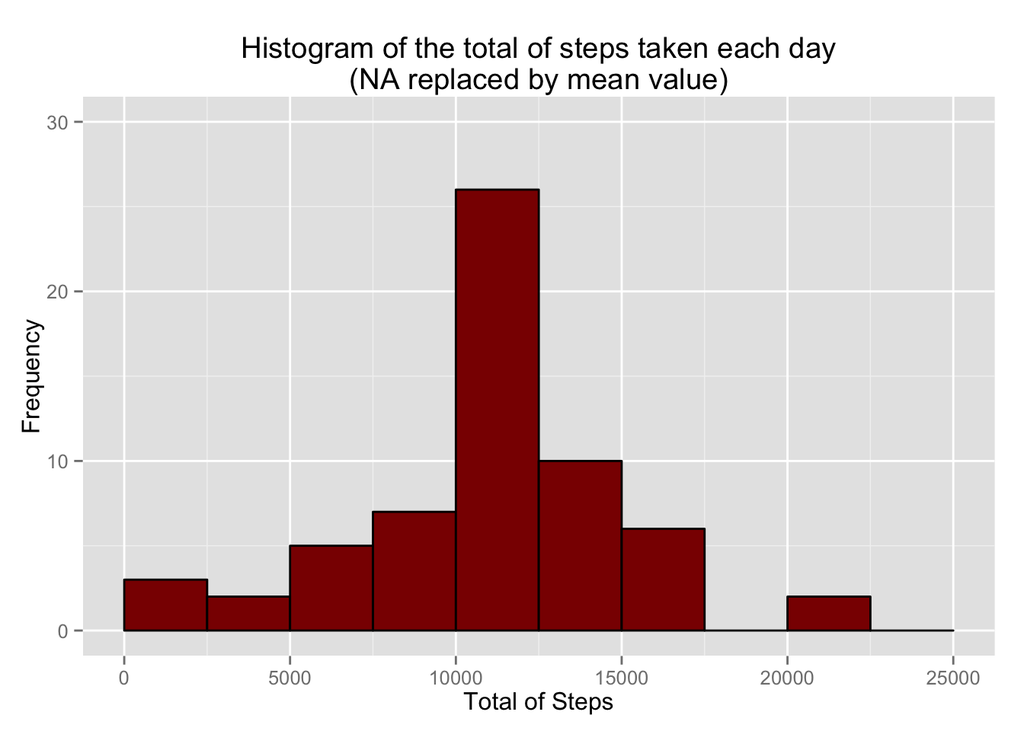

```r
# Importing the ggplot2 library
library(ggplot2)

# Aggregating steps by date
aggregated_activity_by_day <- aggregate(steps ~ date, activity_data, sum, na.rm = TRUE)

# Renaming the second attribute
names(aggregated_activity_by_day)[2] <- "total_steps"

# Ploting the graph
ggplot(aggregated_activity_by_day, aes(x=total_steps)) +
    geom_histogram(binwidth=1000, breaks=seq(from=0, to=25000, by=2500), colour="black", fill="darkred") +
    ylim(0,30) +
    ggtitle("Histogram of the total of steps taken each day\n(NA replaced by mean value)") +
    xlab("Total of Steps") +
    ylab("Frequency")
```

#### Calculating and reporting the mean and median total number of steps taken per day.

```r
# Calculating the mean
mean(aggregated_activity_by_day$total_steps, na.rm=TRUE)
```

```
## [1] 10766.19
```

```r
# Calculating the median
median(aggregated_activity_by_day$total_steps, na.rm=TRUE)
```

```
## [1] 10766.19
```

#### Do these values differ from the estimates from the first part of the assignment?

They do differ but ever so slightly.

### Are there differences in activity patterns between weekdays and weekends?

#### 1. Creating a new factor variable in the dataset with two levels – “weekday” and “weekend” indicating whether a given date is a weekday or weekend day.

```r
head(activity_data)
```

```
##         date weekday interval   steps
## 1 2012-10-01  monday        0 37.3826
## 2 2012-10-01  monday        5 37.3826
## 3 2012-10-01  monday       10 37.3826
## 4 2012-10-01  monday       15 37.3826
## 5 2012-10-01  monday       20 37.3826
## 6 2012-10-01  monday       25 37.3826
```

```r
# Computing the day type (weekend or weekday)
activity_data <- cbind(activity_data,
                  daytype=ifelse(activity_data$weekday == "saturday" |
                                 activity_data$weekday == "sunday",
                                 "weekend", "weekday"))

head(activity_data)
```

```
##         date weekday interval   steps daytype
## 1 2012-10-01  monday        0 37.3826 weekday
## 2 2012-10-01  monday        5 37.3826 weekday
## 3 2012-10-01  monday       10 37.3826 weekday
## 4 2012-10-01  monday       15 37.3826 weekday
## 5 2012-10-01  monday       20 37.3826 weekday
## 6 2012-10-01  monday       25 37.3826 weekday
```

#### 2. Making a panel plot containing a time series plot of the 5-minute interval (x-axis) and the average number of steps taken, averaged across all weekday days or weekend days (y-axis).

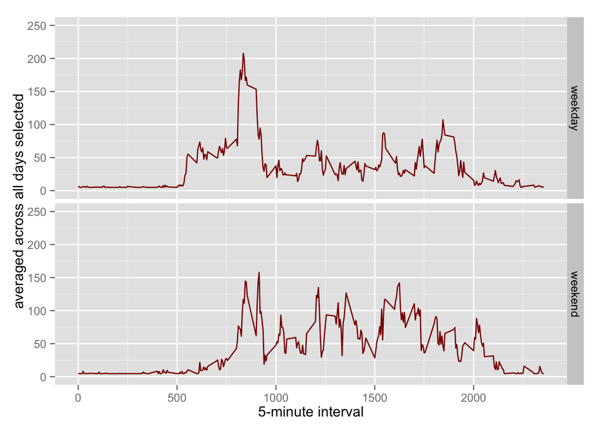

```r
averages_daytype <- aggregate(steps ~ interval + daytype, data=activity_data, mean)
                    ggplot(averages_daytype, aes(interval, steps)) +
                    geom_line(binwidth=100, breaks=seq(from=0, to=3000, by=500), colour="darkred") +
                    ylim(0,250) +
                    facet_grid(daytype ~ .) +
                    xlab("5-minute interval") +
                    ylab("averaged across all days selected")
```